# Assignment_NN_August2020

```python
from google.colab import drive
drive.mount('/content/drive')
```

```python
%tensorflow_version 2.x
import tensorflow
tensorflow.__version__
```

```
'2.3.0'
```

**Import Libraries & Default Settings**

```python
import matplotlib.pyplot as plt
%matplotlib inline

import h5py
import numpy as np

from tensorflow.keras.models import Sequential
from tensorflow.keras.utils import to_categorical
from tensorflow.keras.layers import Activation, Dense, Flatten
from tensorflow.keras.layers import BatchNormalization, Dropout
from tensorflow.keras import optimizers, regularizers
from prettytable import PrettyTable

# Initialize the random number generator
import random
random.seed(0)

# Ignore the warnings
import warnings
warnings.filterwarnings("ignore")
```

```python
#Open the file as readonly
h5f = h5py.File('/content/drive/My Drive/GL/Dataset/SVHN_single_grey1.h5', 'r')
h5f.keys()
```

```
<KeysViewHDF5 ['X_test', 'X_train', 'X_val', 'y_test', 'y_train', 'y_val']>
```

```python
#Load the training, test and validation set
Xtrain = h5f['X_train'][:]
ytrain = h5f['y_train'][:]
Xtest = h5f['X_test'][:]
ytest = h5f['y_test'][:]
```

**Visualizing some images along with there ouput label i.e. y value**

```python
#Method to load data of a particular index from the data
def LoadImage(index):
  plt.title("Label: {}".format(ytrain[index]))
  plt.imshow(Xtrain[index])

def LoadProcessedImage(index):
  plt.title("Label: {}".format(np.argmax(ytrain[index][0:10])))
  plt.imshow(Xtrain[index].reshape(32,32))

def LoadData(func):
  plt.figure(figsize=(20,20))
  j=0
  for i in range(0, 41000, 5000):
    plt.subplot(1, 10, j+1)
    func(i)
    plt.axis('off')
    j+=1
  plt.show()

def DisplayShapeOfData():
  tab = PrettyTable()
  tab.field_names = ["Data", "Shape"]
  tab.add_row(['X Training', Xtrain.shape])
  tab.add_row(['Y Training', ytrain.shape])
  tab.add_row(['X Testing', Xtest.shape])
  tab.add_row(['Y Testing', ytest.shape])
  print(tab)
```

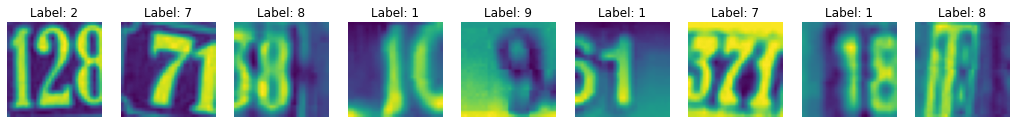

```python
LoadData(LoadImage)
```

*Observation:*

We can see above the images and the corresponding labels which are same as that of the image. In our dataset we are going to looking for single digits hence the labels are stored as a single digit number.

**Shape of the Data**

```python
DisplayShapeOfData()
```

```
+------------+-----------------+
|    Data    |      Shape      |
+------------+-----------------+
| X Training | (42000, 32, 32) |
| Y Training |     (42000,)    |
| X Testing  | (18000, 32, 32) |
| Y Testing  |     (18000,)    |
+------------+-----------------+
```

**Reshaping Data**

```python
Xtrain = Xtrain.reshape(Xtrain.shape[0], -1)
Xtest = Xtest.reshape(Xtest.shape[0], -1)
```

**One-Hot Encoding**

- Convert Class Vectors (ytrain & ytest) to Binary Class Matrix
- Since we are looking for single digits, the number of classes will be 10 (0,1,2,.....,9)

```python
ytrain = to_categorical(ytrain, num_classes = 10)
ytest = to_categorical(ytest, num_classes = 10)
print(ytrain[5000])
```

```
[0. 0. 0. 0. 0. 0. 0. 1. 0. 0.]
```

The output represents correctly the number 7

```python
DisplayShapeOfData()
```

```
+------------+---------------+
|    Data    |     Shape     |
+------------+---------------+
| X Training | (42000, 1024) |
| Y Training |  (42000, 10)  |
| X Testing  | (18000, 1024) |
| Y Testing  |  (18000, 10)  |
+------------+---------------+
```

**Storing Data for Future Computations**

```python
reshaped_Xtrain = Xtrain
reshaped_Xtest = Xtest
reshaped_ytrain = ytrain
reshaped_ytest = ytest
```

**Normalize Features**

- Image has values from 0 to 255 and we will normalize them between 0 and 1.

```python
Xtrain /= 255
Xtest /= 255
```

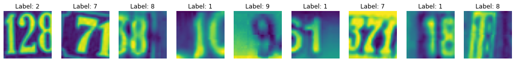

```python
LoadData(LoadProcessedImage)
```

*Observation:*

Even after Reshaping & Normalizing the data we are able to derive the same original image again. This confirms that the data processing was successful.

**Model Building**

1. **Basic NN Model**

   As mentioned in the objective of the project, have created the model architecture with an input layer (dense layer to accept the input), hidden layer starting with a flatten layer followed by dense layers with Relu and Softmax activations & finally the output layer (dense layer with softmax activation)

```python
finalResults = []
outputNodes = 10
hiddenNodes = 256
epoch = 50
shape = Xtrain.shape[1]
adam = optimizers.Adam(amsgrad=True)
l2 = regularizers.l2()
batchSize = 32
```

```python
def NNBasic():
  model = Sequential()
  model.add(Dense(hiddenNodes, input_shape = (shape, ), activation='relu'))
  model.add(Flatten())
  model.add(Dense(hiddenNodes, activation='relu'))
  model.add(Dense(hiddenNodes/2, activation='relu'))
  model.add(Dense(outputNodes, activation='softmax', kernel_regularizer=l2))
  model.summary()
  model.compile(optimizer=adam, loss='categorical_crossentropy',  metrics = ['accuracy'])
   # Early Stop the training if there is no improvement in validation loss for the next 3 epochs
  callback = tensorflow.keras.callbacks.EarlyStopping(monitor='val_loss', patience=3)
  history = model.fit(Xtrain, ytrain, epochs=epoch, validation_data=(Xtest, ytest), verbose = 1, batch_size = batchSize, callbacks = [callback])
  PlotTrainingResults(history.history)
  title = 'Basic NN - Batch Size ({0})'.format(batchSize)
  EvaluateModel(model, title)
```

1. NN Model with Dropout

```python
def NNDropout():
  model = Sequential()
  model.add(Dense(hiddenNodes, input_shape = (shape, ), activation='relu'))
  model.add(Flatten())
  model.add(Dense(hiddenNodes, activation='relu'))
  model.add(Dropout(0.5))
  model.add(Dense(hiddenNodes/2, activation='relu'))
  model.add(Dropout(0.5))
  model.add(Dense(outputNodes, activation='softmax', kernel_regularizer=l2))
  model.summary()
  model.compile(optimizer=adam, loss='categorical_crossentropy',  metrics = ['accuracy'])
  # Early Stop the training if there is no improvement in validation loss for the next 3 epochs
  callback = tensorflow.keras.callbacks.EarlyStopping(monitor='val_loss', patience=3)
  history = model.fit(Xtrain, ytrain, epochs=epoch, validation_data=(Xtest, ytest), verbose = 1, batch_size = batchSize, callbacks = [callback])
  PlotTrainingResults(history.history)
  title = 'NN with Dropout - Batch Size ({0})'.format(batchSize)
  EvaluateModel(model, title)
```

1. NN Model with BatchNormalization

   Introduced BatchNormalization after Input layer & Hidden layers

```python
def NNBatchNormalization():
  model = Sequential()
  model.add(Dense(hiddenNodes, input_shape = (shape, ), activation='relu'))
  model.add(Flatten())
  model.add(BatchNormalization())
  model.add(Dense(hiddenNodes, activation='relu'))
  model.add(BatchNormalization())
  model.add(Dense(hiddenNodes/2, activation='relu'))
  model.add(BatchNormalization())
  model.add(Dense(outputNodes, activation='softmax'))
  model.summary()
  model.compile(optimizer=adam, loss='categorical_crossentropy',  metrics = ['accuracy'])
  # Early Stop the training if there is no improvement in validation loss for the next 3 epochs
  callback = tensorflow.keras.callbacks.EarlyStopping(monitor='val_loss', patience=3)
  history = model.fit(Xtrain, ytrain, epochs=epoch, validation_data=(Xtest, ytest), verbose = 1, batch_size = batchSize, callbacks = [callback])
  PlotTrainingResults(history.history)
  title = 'NN with Batch Normalization - Batch Size ({0})'.format(batchSize)
  EvaluateModel(model, title)
  finalResults.append(["", "", ""])
```

```python
def NNTune():
  model = Sequential()
  model.add(Dense(hiddenNodes, input_shape = (shape, ), activation='relu'))
  model.add(Flatten())
  model.add(Dense(hiddenNodes, activation='relu'))
  model.add(Dense(hiddenNodes/2, activation='relu'))
  model.add(Dense(outputNodes, activation='softmax', kernel_regularizer=l2))
  model.summary()
  model.compile(optimizer=adam, loss='categorical_crossentropy',  metrics = ['accuracy'])
  history = model.fit(Xtrain, ytrain, epochs=epoch, validation_data=(Xtest, ytest), verbose = 1, batch_size = batchSize)
  PlotTrainingResults(history.history)
```

**Function to Plot Graph of Training Results**

```python
def PlotTrainingResults(data):
  plt.figure(figsize=(15,5))

  # summarize history for accuracy
  plt.subplot(1, 2, 1)
  plt.plot(data['accuracy'])
  plt.plot(data['val_accuracy'])
  plt.title('Model Accuracy')
  plt.ylabel('accuracy')
  plt.xlabel('epoch')
  plt.legend(['train', 'validation'], loc='upper left')

  # summarize history for loss
  plt.subplot(1, 2, 2)
  plt.plot(data['loss'])
  plt.plot(data['val_loss'])
  plt.title('Model Loss')
  plt.ylabel('loss')
  plt.xlabel('epoch')
  plt.legend(['train', 'validation'], loc='upper right')
  plt.show()
```

**Function to Evaluate Model**

```python
def EvaluateModel(model, modelName):
  result = model.evaluate(Xtest, ytest)
  print('------------------ Model Evaluation Results ------------------')
  print('Test Loss: ', result[0])
  print('Test Accuracy: ', result[1])
  finalResults.append([modelName, result[0], result[1]])
```

**Function to Display Results**

```python
def DisplayFinalResults():
  tab = PrettyTable()
  tab.field_names = ["Model Type", "Testing Loss", "Testing Accuracy"]
  for i in finalResults:
    tab.add_row([i[0], i[1], i[2]])
  print(tab)
```

**Model Execution**

```
Model: "sequential"
_________________________________________________________________
Layer (type)                 Output Shape              Param #
=================================================================
dense (Dense)                (None, 256)               262400
_________________________________________________________________
flatten (Flatten)            (None, 256)               0
_________________________________________________________________
dense_1 (Dense)              (None, 256)               65792
_________________________________________________________________
dense_2 (Dense)              (None, 128)               32896
_________________________________________________________________
dense_3 (Dense)              (None, 10)                1290
=================================================================
Total params: 362,378
Trainable params: 362,378
Non-trainable params: 0
_________________________________________________________________
```

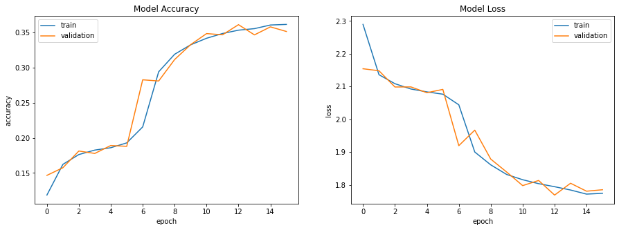

```
------------------ Model Evaluation Results ------------------
Test Loss:  1.7847974300384521
Test Accuracy:  0.35111111402511597
```

```python
NNBasic()
```

```
Model: "sequential_1"
_________________________________________________________________
Layer (type)                 Output Shape              Param #
=================================================================
dense_4 (Dense)              (None, 256)               262400
_________________________________________________________________
flatten_1 (Flatten)          (None, 256)               0
_________________________________________________________________
dense_5 (Dense)              (None, 256)               65792
_________________________________________________________________
dropout (Dropout)            (None, 256)               0
_________________________________________________________________
dense_6 (Dense)              (None, 128)               32896
_________________________________________________________________
dropout_1 (Dropout)          (None, 128)               0
_________________________________________________________________
dense_7 (Dense)              (None, 10)                1290
=================================================================
Total params: 362,378
Trainable params: 362,378
Non-trainable params: 0
_________________________________________________________________
```

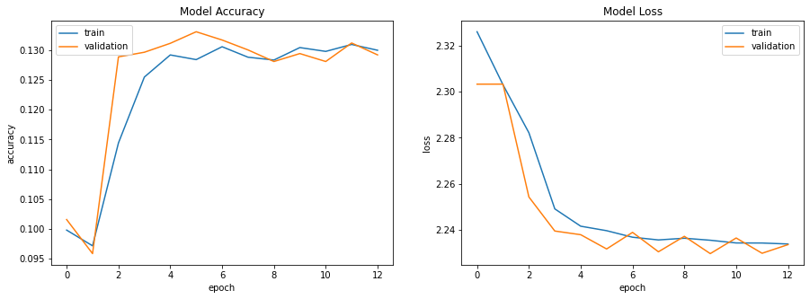

```
------------------ Model Evaluation Results ------------------
Test Loss:  2.233586549758911
Test Accuracy:  0.12922222912311554
```

```python
NNDropout()
```

```
Model: "sequential_2"
_________________________________________________________________
Layer (type)                 Output Shape              Param #
=================================================================
dense_8 (Dense)              (None, 256)               262400
_________________________________________________________________
flatten_2 (Flatten)          (None, 256)               0
_________________________________________________________________
batch_normalization (BatchNo (None, 256)               1024
_________________________________________________________________
dense_9 (Dense)              (None, 256)               65792
_________________________________________________________________
batch_normalization_1 (Batch (None, 256)               1024
_________________________________________________________________
dense_10 (Dense)             (None, 128)               32896
_________________________________________________________________
batch_normalization_2 (Batch (None, 128)               512
_________________________________________________________________
dense_11 (Dense)             (None, 10)                1290
=================================================================
Total params: 364,938
Trainable params: 363,658
Non-trainable params: 1,280
_________________________________________________________________
```

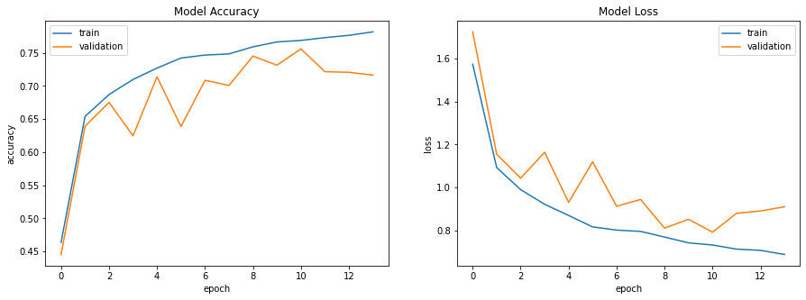

```
------------------ Model Evaluation Results ------------------
Test Loss:  0.9108253121376038
Test Accuracy:  0.7165555357933044
```

```python
NNBatchNormalization()
```

```python
DisplayFinalResults()
```

```
+-----------------------------------------------+--------------------+---------------------+
|                   Model Type                  |    Testing Loss    |   Testing Accuracy  |
+-----------------------------------------------+--------------------+---------------------+
|           Basic NN - Batch Size (32)          | 1.7847974300384521 | 0.35111111402511597 |
|       NN with Dropout - Batch Size (32)       | 2.233586549758911  | 0.12922222912311554 |
| NN with Batch Normalization - Batch Size (32) | 0.9108253121376038 |  0.7165555357933044 |
|                                               |                    |                     |
+-----------------------------------------------+--------------------+---------------------+
```

**Observations :**

- Basic NN Model has performed below average.
- NN with Dropout model has the lowest accuracy.
- NN with BatchNormalization has the highest accuracy among the three models.

Now, let us increase the batch size and check the performance of the same models.

```
Model: "sequential_3"
_________________________________________________________________
Layer (type)                 Output Shape              Param #
=================================================================
dense_12 (Dense)             (None, 256)               262400
_________________________________________________________________
flatten_3 (Flatten)          (None, 256)               0
_________________________________________________________________
dense_13 (Dense)             (None, 256)               65792
_________________________________________________________________
dense_14 (Dense)             (None, 128)               32896
_________________________________________________________________
dense_15 (Dense)             (None, 10)                1290
=================================================================
Total params: 362,378
Trainable params: 362,378
Non-trainable params: 0
_________________________________________________________________
```

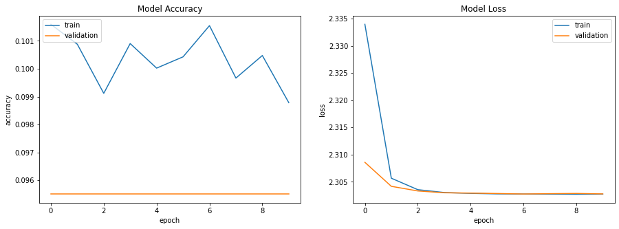

```
------------------ Model Evaluation Results ------------------
Test Loss:  2.302772283554077
Test Accuracy:  0.09549999982118607
```

```python
batchSize=64
NNBasic()
```

```
Model: "sequential_4"
_________________________________________________________________
Layer (type)                 Output Shape              Param #
=================================================================
dense_16 (Dense)             (None, 256)               262400
_________________________________________________________________
flatten_4 (Flatten)          (None, 256)               0
_________________________________________________________________
dense_17 (Dense)             (None, 256)               65792
_________________________________________________________________
dropout_2 (Dropout)          (None, 256)               0
_________________________________________________________________
dense_18 (Dense)             (None, 128)               32896
_________________________________________________________________
dropout_3 (Dropout)          (None, 128)               0
_________________________________________________________________
dense_19 (Dense)             (None, 10)                1290
=================================================================
Total params: 362,378
Trainable params: 362,378
Non-trainable params: 0
_________________________________________________________________
```

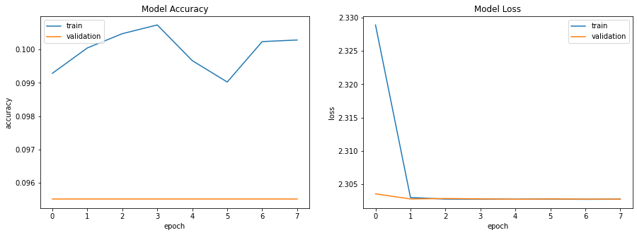

```
------------------ Model Evaluation Results ------------------
Test Loss:  2.302738666534424
Test Accuracy:  0.09549999982118607
```

```python
NNDropout()
```

```
Model: "sequential_5"
_________________________________________________________________
Layer (type)                 Output Shape              Param #
=================================================================
dense_20 (Dense)             (None, 256)               262400
_________________________________________________________________
flatten_5 (Flatten)          (None, 256)               0
_________________________________________________________________
batch_normalization_3 (Batch (None, 256)               1024
_________________________________________________________________
dense_21 (Dense)             (None, 256)               65792
_________________________________________________________________
batch_normalization_4 (Batch (None, 256)               1024
_________________________________________________________________
dense_22 (Dense)             (None, 128)               32896
_________________________________________________________________
batch_normalization_5 (Batch (None, 128)               512
_________________________________________________________________
dense_23 (Dense)             (None, 10)                1290
=================================================================
Total params: 364,938
Trainable params: 363,658
Non-trainable params: 1,280
_________________________________________________________________
```

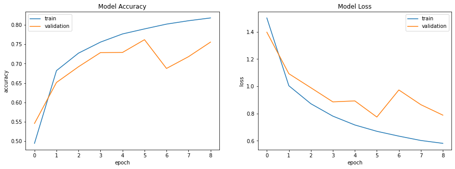

```
------------------ Model Evaluation Results ------------------
Test Loss:  0.7882211208343506
Test Accuracy:  0.7556111216545105
```

```python
NNBatchNormalization()
```

```python
DisplayFinalResults()
```

```
+-----------------------------------------------+--------------------+---------------------+
|                   Model Type                  |    Testing Loss    |   Testing Accuracy  |
+-----------------------------------------------+--------------------+---------------------+
|           Basic NN - Batch Size (32)          | 1.7847974300384521 | 0.35111111402511597 |
|       NN with Dropout - Batch Size (32)       | 2.233586549758911  | 0.12922222912311554 |
| NN with Batch Normalization - Batch Size (32) | 0.9108253121376038 |  0.7165555357933044 |
|                                               |                    |                     |
|           Basic NN - Batch Size (64)          | 2.302772283554077  | 0.09549999982118607 |
|       NN with Dropout - Batch Size (64)       | 2.302738666534424  | 0.09549999982118607 |
| NN with Batch Normalization - Batch Size (64) | 0.7882211208343506 |  0.7556111216545105 |
|                                               |                    |                     |
+-----------------------------------------------+--------------------+---------------------+
```

**Observations :**

- Basic NN Model has under performed and has the lowest accuracy.
- NN with Dropout model has lowest accuracy. No significant progress.
- NN with BatchNormalization again has the highest accuracy among the three models.

Again let us increase the batch size and check the performance of the same models.

```
Model: "sequential_6"
_________________________________________________________________
Layer (type)                 Output Shape              Param #
=================================================================
dense_24 (Dense)             (None, 256)               262400
_________________________________________________________________
flatten_6 (Flatten)          (None, 256)               0
_________________________________________________________________
dense_25 (Dense)             (None, 256)               65792
_________________________________________________________________
dense_26 (Dense)             (None, 128)               32896
_________________________________________________________________
dense_27 (Dense)             (None, 10)                1290
=================================================================
Total params: 362,378
Trainable params: 362,378
Non-trainable params: 0
_________________________________________________________________
```

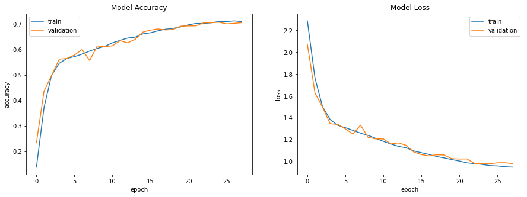

```
------------------ Model Evaluation Results ------------------
Test Loss:  0.9819604754447937
Test Accuracy:  0.7048888802528381
```

```python
batchSize=128
NNBasic()
```

```
Model: "sequential_7"
_________________________________________________________________
Layer (type)                 Output Shape              Param #
=================================================================
dense_28 (Dense)             (None, 256)               262400
_________________________________________________________________
flatten_7 (Flatten)          (None, 256)               0
_________________________________________________________________
dense_29 (Dense)             (None, 256)               65792
_________________________________________________________________
dropout_4 (Dropout)          (None, 256)               0
_________________________________________________________________
dense_30 (Dense)             (None, 128)               32896
_________________________________________________________________
dropout_5 (Dropout)          (None, 128)               0
_________________________________________________________________
dense_31 (Dense)             (None, 10)                1290
=================================================================
Total params: 362,378
Trainable params: 362,378
Non-trainable params: 0
_________________________________________________________________
```

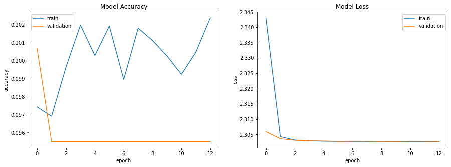

```
------------------ Model Evaluation Results ------------------
Test Loss:  2.302795648574829
Test Accuracy:  0.09549999982118607
```

```python
NNDropout()
```

```
Model: "sequential_8"
_________________________________________________________________
Layer (type)                 Output Shape              Param #
=================================================================
dense_32 (Dense)             (None, 256)               262400
_________________________________________________________________
flatten_8 (Flatten)          (None, 256)               0
_________________________________________________________________
batch_normalization_6 (Batch (None, 256)               1024
_________________________________________________________________
dense_33 (Dense)             (None, 256)               65792
_________________________________________________________________
batch_normalization_7 (Batch (None, 256)               1024
_________________________________________________________________
dense_34 (Dense)             (None, 128)               32896
_________________________________________________________________
batch_normalization_8 (Batch (None, 128)               512
_________________________________________________________________
dense_35 (Dense)             (None, 10)                1290
=================================================================
Total params: 364,938
Trainable params: 363,658
Non-trainable params: 1,280
_________________________________________________________________
```

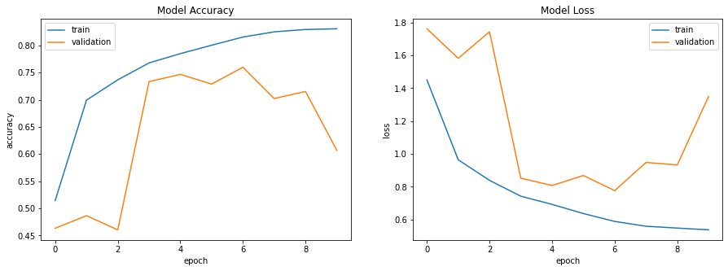

```
------------------ Model Evaluation Results ------------------
Test Loss:  1.3504443168640137
Test Accuracy:  0.6068333387374878
```

```python
NNBatchNormalization()
```

```python
DisplayFinalResults()
```

```
+------------------------------------------------+--------------------+---------------------+
|                   Model Type                   |    Testing Loss    |   Testing Accuracy  |
+------------------------------------------------+--------------------+---------------------+
|           Basic NN - Batch Size (32)           | 1.7847974300384521 | 0.35111111402511597 |
|       NN with Dropout - Batch Size (32)        | 2.233586549758911  | 0.12922222912311554 |
| NN with Batch Normalization - Batch Size (32)  | 0.9108253121376038 |  0.7165555357933044 |
|                                                |                    |                     |
|           Basic NN - Batch Size (64)           | 2.302772283554077  | 0.09549999982118607 |
|       NN with Dropout - Batch Size (64)        | 2.302738666534424  | 0.09549999982118607 |
| NN with Batch Normalization - Batch Size (64)  | 0.7882211208343506 |  0.7556111216545105 |
|                                                |                    |                     |
|          Basic NN - Batch Size (128)           | 0.9819604754447937 |  0.7048888802528381 |
|       NN with Dropout - Batch Size (128)       | 2.302795648574829  | 0.09549999982118607 |
| NN with Batch Normalization - Batch Size (128) | 1.3504443168640137 |  0.6068333387374878 |
|                                                |                    |                     |
+------------------------------------------------+--------------------+---------------------+
```

**Observations :**

- Basic NN Model has performed the best and has the highest accuracy.
- NN with Dropout model has under performed and has the lowest accuracy.
- NN with BatchNormalization has under performed with drop in accuracy.

Again let us increase the batch size and check the performance of the same models.

```
Model: "sequential_9"
_________________________________________________________________
Layer (type)                 Output Shape              Param #
=================================================================
dense_36 (Dense)             (None, 256)               262400
_________________________________________________________________
flatten_9 (Flatten)          (None, 256)               0
_________________________________________________________________
dense_37 (Dense)             (None, 256)               65792
_________________________________________________________________
dense_38 (Dense)             (None, 128)               32896
_________________________________________________________________
dense_39 (Dense)             (None, 10)                1290
=================================================================
Total params: 362,378
Trainable params: 362,378
Non-trainable params: 0
_________________________________________________________________
```

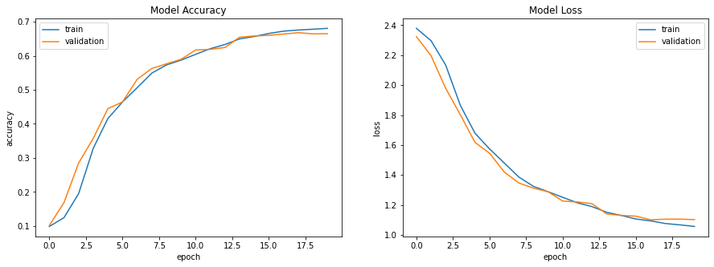

```
------------------ Model Evaluation Results ------------------
Test Loss:  1.1024497747421265
Test Accuracy:  0.6649444699287415
```

```python
batchSize=256
NNBasic()
```

```
Model: "sequential_10"
_________________________________________________________________
Layer (type)                 Output Shape              Param #
=================================================================
dense_40 (Dense)             (None, 256)               262400
_________________________________________________________________
flatten_10 (Flatten)         (None, 256)               0
_________________________________________________________________
dense_41 (Dense)             (None, 256)               65792
_________________________________________________________________
dropout_6 (Dropout)          (None, 256)               0
_________________________________________________________________
dense_42 (Dense)             (None, 128)               32896
_________________________________________________________________
dropout_7 (Dropout)          (None, 128)               0
_________________________________________________________________
dense_43 (Dense)             (None, 10)                1290
=================================================================
Total params: 362,378
Trainable params: 362,378
Non-trainable params: 0
_________________________________________________________________
```

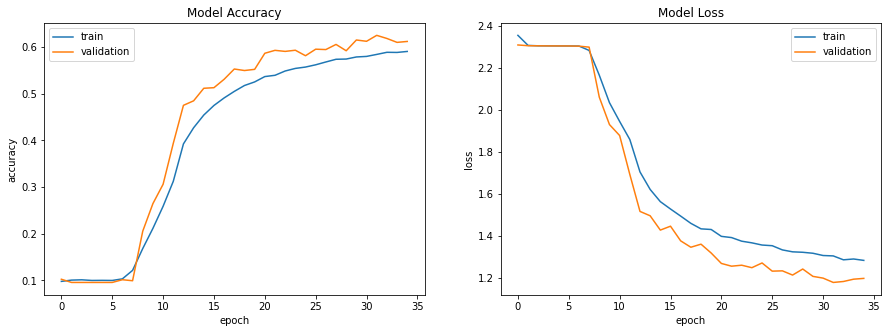

```
------------------ Model Evaluation Results ------------------
Test Loss:  1.1969982385635376
Test Accuracy:  0.6121110916137695
```

```python
NNDropout()
```

```
Model: "sequential_11"
_________________________________________________________________
Layer (type)                 Output Shape              Param #
=================================================================
dense_44 (Dense)             (None, 256)               262400
_________________________________________________________________
flatten_11 (Flatten)         (None, 256)               0
_________________________________________________________________
batch_normalization_9 (Batch (None, 256)               1024
_________________________________________________________________
dense_45 (Dense)             (None, 256)               65792
_________________________________________________________________
batch_normalization_10 (Batc (None, 256)               1024
_________________________________________________________________
dense_46 (Dense)             (None, 128)               32896
_________________________________________________________________
batch_normalization_11 (Batc (None, 128)               512
_________________________________________________________________
dense_47 (Dense)             (None, 10)                1290
=================================================================
Total params: 364,938
Trainable params: 363,658
Non-trainable params: 1,280
_________________________________________________________________
```

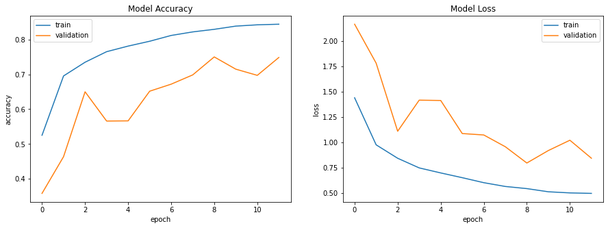

```
------------------ Model Evaluation Results ------------------
Test Loss:  0.8440158367156982
Test Accuracy:  0.7483333349227905
```

```python
NNBatchNormalization()
```

```python
DisplayFinalResults()
```

```
+------------------------------------------------+--------------------+---------------------+
|                   Model Type                   |    Testing Loss    |   Testing Accuracy  |
+------------------------------------------------+--------------------+---------------------+
|           Basic NN - Batch Size (32)           | 1.7847974300384521 | 0.35111111402511597 |
|       NN with Dropout - Batch Size (32)        | 2.233586549758911  | 0.12922222912311554 |
| NN with Batch Normalization - Batch Size (32)  | 0.9108253121376038 |  0.7165555357933044 |
|                                                |                    |                     |
|           Basic NN - Batch Size (64)           | 2.302772283554077  | 0.09549999982118607 |
|       NN with Dropout - Batch Size (64)        | 2.302738666534424  | 0.09549999982118607 |
| NN with Batch Normalization - Batch Size (64)  | 0.7882211208343506 |  0.7556111216545105 |
|                                                |                    |                     |
|          Basic NN - Batch Size (128)           | 0.9819604754447937 |  0.7048888802528381 |
|       NN with Dropout - Batch Size (128)       | 2.302795648574829  | 0.09549999982118607 |
| NN with Batch Normalization - Batch Size (128) | 1.3504443168640137 |  0.6068333387374878 |
|                                                |                    |                     |
|          Basic NN - Batch Size (256)           | 1.1024497747421265 |  0.6649444699287415 |
|       NN with Dropout - Batch Size (256)       | 1.1969982385635376 |  0.6121110916137695 |
| NN with Batch Normalization - Batch Size (256) | 0.8440158367156982 |  0.7483333349227905 |
|                                                |                    |                     |
+------------------------------------------------+--------------------+---------------------+
```

**Observations :**

- Basic NN Model has a drop in accuracy as compared to previous one.
- NN with Dropout model has performed very well with a sudden increase in the accuracy
- NN with BatchNormalization has performed well then the previous time with a good jump in accuracy.

Again let us increase the batch size and check the performance of the same models.

```
Model: "sequential_12"
_________________________________________________________________
Layer (type)                 Output Shape              Param #
=================================================================
dense_48 (Dense)             (None, 256)               262400
_________________________________________________________________
flatten_12 (Flatten)         (None, 256)               0
_________________________________________________________________
dense_49 (Dense)             (None, 256)               65792
_________________________________________________________________
dense_50 (Dense)             (None, 128)               32896
_________________________________________________________________
dense_51 (Dense)             (None, 10)                1290
=================================================================
Total params: 362,378
Trainable params: 362,378
Non-trainable params: 0
_________________________________________________________________
```

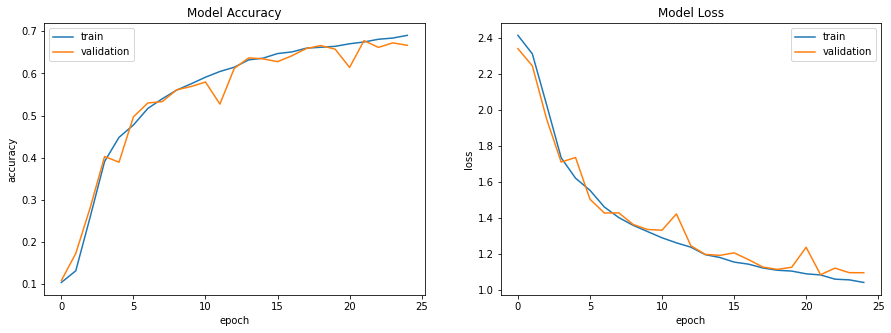

```
------------------ Model Evaluation Results ------------------
Test Loss:  1.0953646898269653
Test Accuracy:  0.6664999723434448
```

```python
batchSize=512
NNBasic()
```

```
Model: "sequential_13"
_________________________________________________________________
Layer (type)                 Output Shape              Param #
=================================================================
dense_52 (Dense)             (None, 256)               262400
_________________________________________________________________
flatten_13 (Flatten)         (None, 256)               0
_________________________________________________________________
dense_53 (Dense)             (None, 256)               65792
_________________________________________________________________
dropout_8 (Dropout)          (None, 256)               0
_________________________________________________________________
dense_54 (Dense)             (None, 128)               32896
_________________________________________________________________
dropout_9 (Dropout)          (None, 128)               0
_________________________________________________________________
dense_55 (Dense)             (None, 10)                1290
=================================================================
Total params: 362,378
Trainable params: 362,378
Non-trainable params: 0
_________________________________________________________________
```

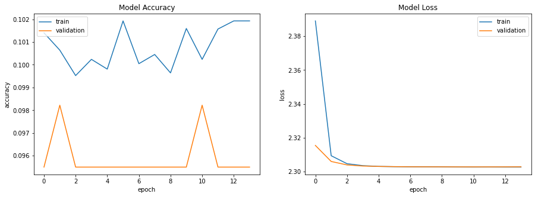

```
------------------ Model Evaluation Results ------------------
Test Loss:  2.302806854248047
Test Accuracy:  0.09549999982118607
```

```python
NNDropout()
```

```
Model: "sequential_14"
_________________________________________________________________
Layer (type)                 Output Shape              Param #
=================================================================
dense_56 (Dense)             (None, 256)               262400
_________________________________________________________________
flatten_14 (Flatten)         (None, 256)               0
_________________________________________________________________
batch_normalization_12 (Batc (None, 256)               1024
_________________________________________________________________
dense_57 (Dense)             (None, 256)               65792
_________________________________________________________________
batch_normalization_13 (Batc (None, 256)               1024
_________________________________________________________________
dense_58 (Dense)             (None, 128)               32896
_________________________________________________________________
batch_normalization_14 (Batc (None, 128)               512
_________________________________________________________________
dense_59 (Dense)             (None, 10)                1290
=================================================================
Total params: 364,938
Trainable params: 363,658
Non-trainable params: 1,280
_________________________________________________________________
```

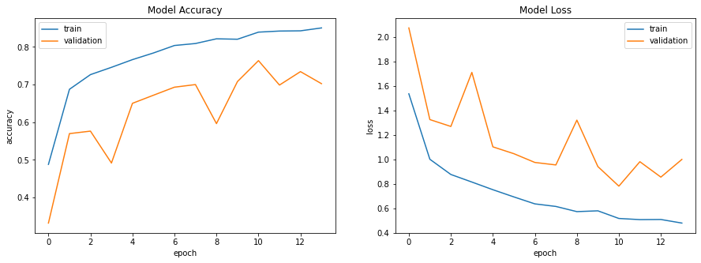

```
------------------ Model Evaluation Results ------------------
Test Loss:  1.0004892349243164
Test Accuracy:  0.7022222280502319
```

```python
NNBatchNormalization()
```

```python
DisplayFinalResults()
```

```
+------------------------------------------------+--------------------+---------------------+
|                   Model Type                   |    Testing Loss    |   Testing Accuracy  |
+------------------------------------------------+--------------------+---------------------+
|           Basic NN - Batch Size (32)           | 1.7847974300384521 | 0.35111111402511597 |
|       NN with Dropout - Batch Size (32)        | 2.233586549758911  | 0.12922222912311554 |
| NN with Batch Normalization - Batch Size (32)  | 0.9108253121376038 |  0.7165555357933044 |
|                                                |                    |                     |
|           Basic NN - Batch Size (64)           | 2.302772283554077  | 0.09549999982118607 |
|       NN with Dropout - Batch Size (64)        | 2.302738666534424  | 0.09549999982118607 |
| NN with Batch Normalization - Batch Size (64)  | 0.7882211208343506 |  0.7556111216545105 |
|                                                |                    |                     |
|          Basic NN - Batch Size (128)           | 0.9819604754447937 |  0.7048888802528381 |
|       NN with Dropout - Batch Size (128)       | 2.302795648574829  | 0.09549999982118607 |
| NN with Batch Normalization - Batch Size (128) | 1.3504443168640137 |  0.6068333387374878 |
|                                                |                    |                     |
|          Basic NN - Batch Size (256)           | 1.1024497747421265 |  0.6649444699287415 |
|       NN with Dropout - Batch Size (256)       | 1.1969982385635376 |  0.6121110916137695 |
| NN with Batch Normalization - Batch Size (256) | 0.8440158367156982 |  0.7483333349227905 |
|                                                |                    |                     |
|          Basic NN - Batch Size (512)           | 1.0953646898269653 |  0.6664999723434448 |
|       NN with Dropout - Batch Size (512)       | 2.302806854248047  | 0.09549999982118607 |
| NN with Batch Normalization - Batch Size (512) | 1.0004892349243164 |  0.7022222280502319 |
|                                                |                    |                     |
+------------------------------------------------+--------------------+---------------------+
```

**Observations :**

**Hyper Parameter Tuning**

```
Model: "sequential_15"
_________________________________________________________________
Layer (type)                 Output Shape              Param #
=================================================================
dense_60 (Dense)             (None, 256)               262400
_________________________________________________________________
flatten_15 (Flatten)         (None, 256)               0
_________________________________________________________________
dense_61 (Dense)             (None, 256)               65792
_________________________________________________________________
dense_62 (Dense)             (None, 128)               32896
_________________________________________________________________
dense_63 (Dense)             (None, 10)                1290
=================================================================
Total params: 362,378
Trainable params: 362,378
Non-trainable params: 0
_________________________________________________________________
```

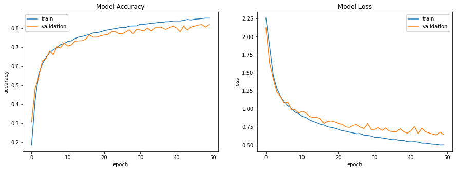

```
Try 1/5: lr: 0.00017385392547440774, Lambda: 0.0002344100208936426

Model: "sequential_16"
_________________________________________________________________
Layer (type)                 Output Shape              Param #
=================================================================
dense_64 (Dense)             (None, 256)               262400
_________________________________________________________________
flatten_16 (Flatten)         (None, 256)               0
_________________________________________________________________
dense_65 (Dense)             (None, 256)               65792
_________________________________________________________________
dense_66 (Dense)             (None, 128)               32896
_________________________________________________________________
dense_67 (Dense)             (None, 10)                1290
=================================================================
Total params: 362,378
Trainable params: 362,378
Non-trainable params: 0
_________________________________________________________________
```

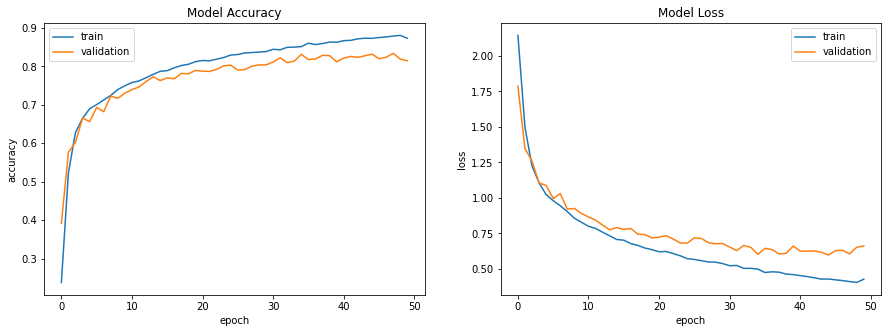

```
Try 2/5: lr: 0.0004677518637772728, Lambda: 0.0003002779859828413

Model: "sequential_17"
_________________________________________________________________
Layer (type)                 Output Shape              Param #
=================================================================
dense_68 (Dense)             (None, 256)               262400
_________________________________________________________________
flatten_17 (Flatten)         (None, 256)               0
_________________________________________________________________
dense_69 (Dense)             (None, 256)               65792
_________________________________________________________________
dense_70 (Dense)             (None, 128)               32896
_________________________________________________________________
dense_71 (Dense)             (None, 10)                1290
=================================================================
Total params: 362,378
Trainable params: 362,378
Non-trainable params: 0
_________________________________________________________________
```

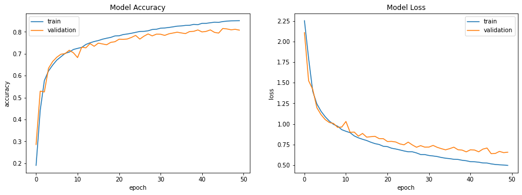

```
Try 3/5: lr: 0.00019383945729234403, Lambda: 0.00012650791500994348

Model: "sequential_18"
_________________________________________________________________
Layer (type)                 Output Shape              Param #
=================================================================
dense_72 (Dense)             (None, 256)               262400
_________________________________________________________________
flatten_18 (Flatten)         (None, 256)               0
_________________________________________________________________
dense_73 (Dense)             (None, 256)               65792
_________________________________________________________________
dense_74 (Dense)             (None, 128)               32896
_________________________________________________________________
dense_75 (Dense)             (None, 10)                1290
=================================================================
Total params: 362,378
Trainable params: 362,378
Non-trainable params: 0
_________________________________________________________________
```

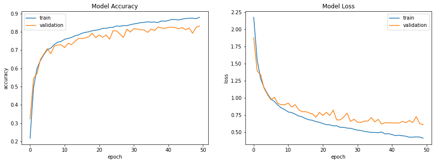

```
Try 4/5: lr: 0.0004244990914475667, Lambda: 0.0002898516651495823

Model: "sequential_19"
_________________________________________________________________
Layer (type)                 Output Shape              Param #
=================================================================
dense_76 (Dense)             (None, 256)               262400
_________________________________________________________________
flatten_19 (Flatten)         (None, 256)               0
_________________________________________________________________
dense_77 (Dense)             (None, 256)               65792
_________________________________________________________________
dense_78 (Dense)             (None, 128)               32896
_________________________________________________________________
dense_79 (Dense)             (None, 10)                1290
=================================================================
Total params: 362,378
Trainable params: 362,378
Non-trainable params: 0
_________________________________________________________________
```

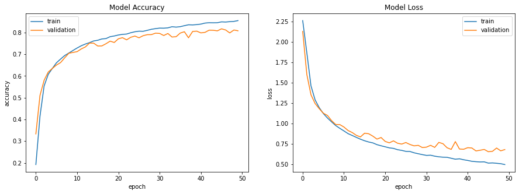

```
Try 5/5: lr: 0.00017484978965743637, Lambda: 0.0002935088114412413
```

```python
import math
batchSize = 256
iter = 6
for k in range(1,iter):
    lr = math.pow(10, np.random.uniform(-3.3, -3.9))
    Lambda = math.pow(10, np.random.uniform(-3.3, -3.9))
    adam = optimizers.Adam(amsgrad=True, learning_rate=lr)
    l2 = regularizers.l2(Lambda)
    NNTune()
    print("Try {0}/{1}: lr: {2}, Lambda: {3}\n".format(k, iter-1, lr, Lambda))
```

**Observation :**

**Re-Evaluate Model with Best Hyperparameters**

```python
lr = 4.2e-4
Lambda = 2.8e-4
batchSize = 256
adam = optimizers.Adam(amsgrad=True, learning_rate=lr)
l2 = regularizers.l2(Lambda)
```

```
Model: "sequential_21"
_________________________________________________________________
Layer (type)                 Output Shape              Param #
=================================================================
dense_84 (Dense)             (None, 256)               262400
_________________________________________________________________
flatten_21 (Flatten)         (None, 256)               0
_________________________________________________________________
dense_85 (Dense)             (None, 256)               65792
_________________________________________________________________
dense_86 (Dense)             (None, 128)               32896
_________________________________________________________________
dense_87 (Dense)             (None, 10)                1290
=================================================================
Total params: 362,378
Trainable params: 362,378
Non-trainable params: 0
_________________________________________________________________
```

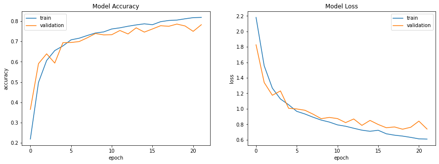

```
------------------ Model Evaluation Results ------------------
Test Loss:  0.7385697960853577
Test Accuracy:  0.7826111316680908
```

```python
NNBasic()
```

```python
DisplayFinalResults()
```

```
+------------------------------------------------+--------------------+---------------------+
|                   Model Type                   |    Testing Loss    |   Testing Accuracy  |
+------------------------------------------------+--------------------+---------------------+
|           Basic NN - Batch Size (32)           | 1.7847974300384521 | 0.35111111402511597 |
|       NN with Dropout - Batch Size (32)        | 2.233586549758911  | 0.12922222912311554 |
| NN with Batch Normalization - Batch Size (32)  | 0.9108253121376038 |  0.7165555357933044 |
|                                                |                    |                     |
|           Basic NN - Batch Size (64)           | 2.302772283554077  | 0.09549999982118607 |
|       NN with Dropout - Batch Size (64)        | 2.302738666534424  | 0.09549999982118607 |
| NN with Batch Normalization - Batch Size (64)  | 0.7882211208343506 |  0.7556111216545105 |
|                                                |                    |                     |
|          Basic NN - Batch Size (128)           | 0.9819604754447937 |  0.7048888802528381 |
|       NN with Dropout - Batch Size (128)       | 2.302795648574829  | 0.09549999982118607 |
| NN with Batch Normalization - Batch Size (128) | 1.3504443168640137 |  0.6068333387374878 |
|                                                |                    |                     |
|          Basic NN - Batch Size (256)           | 1.1024497747421265 |  0.6649444699287415 |
|       NN with Dropout - Batch Size (256)       | 1.1969982385635376 |  0.6121110916137695 |
| NN with Batch Normalization - Batch Size (256) | 0.8440158367156982 |  0.7483333349227905 |
|                                                |                    |                     |
|          Basic NN - Batch Size (512)           | 1.0953646898269653 |  0.6664999723434448 |
|       NN with Dropout - Batch Size (512)       | 2.302806854248047  | 0.09549999982118607 |
| NN with Batch Normalization - Batch Size (512) | 1.0004892349243164 |  0.7022222280502319 |
|                                                |                    |                     |
|          Basic NN - Batch Size (256)           | 0.7385697960853577 |  0.7826111316680908 |
+------------------------------------------------+--------------------+---------------------+
```

**Conclusion :**

- We trained 3 different models namely, Basic NN, With Dropuout & With Batch Normalization. We trained them for different batch size of 32, 63, 128, 256 & 512.
- We got the highest results with for batch size 64 & 256 with around 75% accuracy using the NN with Batch Normalization
- After tuning the hyperparameters i.e. learning rate & regularization lambda of the Basic NN Model with batch size 256 we are able to achieve a higher accuracy with around 78% accuracy